# GenoSee Business Model

Omer Perach

2020-07-30

## Executive Summary

Wordlwide climate change and decrease in arable lands and lands under permanent crops constitute a major concern for future food safety. Private and goverment based breeding programs working constantly to develop elite crops in order to meet the future demand to feed 10 billion people by 2050. Under these constraints, to meet the rising demand for food, agricultural production must increase by an estimated 50% without greatly increasing water usage or expanding the total land area dedicated to agriculture. The era of data enable us to make processes highly effieciet for companies and organisations. This is also true for the plant breeding industry, huge amount of data is recorded and collected - genotype, phenotype, environmental etc. Before inferring and analyzing the data, it should be transformed into findable, available, identifiable, reusable database. GenoSee is a one stop shop for all the breeding program associates in which let them focus in their job - developing elite crops - while letting GenoSee handle the data related work. GenoSee estimate that it will reach 50 paying breeding programs worldwide during the first four years. GenoSee is asking for **$1M** dollars for the first phase of development and **$500K** for the second phase of devlopment. Following our assumptions we calculte positive **NPV**.

## Assumptions

1. Thousands open plant breeding programs worldwide.
2. Phase 1 one year to MVP and reaching first customers.
3. Phase 2 one year for improvement and growth.
4. We will look on the next 7 years.
5. Tax rate 38%.
6. Discount rate 12%.
7. Depreciation 4 years straight line.

## CAPEX Block

We will start by creating a depreciation matrix for the capital investment of the company. We will assume 4 years straight line depreciation that will taken into account only until it can be applied against taxable profit .

```r
kHorizon<-7 # The model Horizon
year<-1:kHorizon # A sequence to represent the horizon years
kTaxRate<-38 # Tax percentage
kDiscountrate<-12 # Discount rate percentage per year for NPV calculations.
kDeprPer<-4 #month, the deprciation sheduale for the capital
p1.dur<-1 #Duration phase one in year
p2.dur<-1 #Duration phase 2 in year
p1.capex<-1000000 #Investment for phase 1.
p2.capex<-500000 #Investment phase 2.
maint.capex<-0 # Additional parameter nit used.
time.to.peak.sales<-3 #Time to reach 100 breedings programs.
mkt.demand<-50 # Market demand after 4 years.
phase <- (year <= p1.dur) * 1 +
(year > p1.dur & year <= (p1.dur + p2.dur)) * 2 +
(year > (p1.dur + p2.dur)) * 3
capex<-(phase==1)*p1.capex/p1.dur+(phase==2)*p2.capex/p2.dur+(phase==3)*maint.capex
depr.matrix <-
t(sapply(year, function(y)
ifelse(y <= p1.dur & year > 0,0,ifelse(
y == (p1.dur + 1) & year < y + kDeprPer & year >= y,
p1.capex / kDeprPer,
ifelse((year >= y) & (year < (y + kDeprPer)),
capex[y - 1] / kDeprPer, 0)
)
)
)
)
depr.matrix
```

```
##      [,1]   [,2]   [,3]   [,4]   [,5]   [,6] [,7]
## [1,]    0      0      0      0      0      0    0
## [2,]    0 250000 250000 250000 250000      0    0
## [3,]    0      0 125000 125000 125000 125000    0
## [4,]    0      0      0      0      0      0    0
## [5,]    0      0      0      0      0      0    0
## [6,]    0      0      0      0      0      0    0
## [7,]    0      0      0      0      0      0    0
```

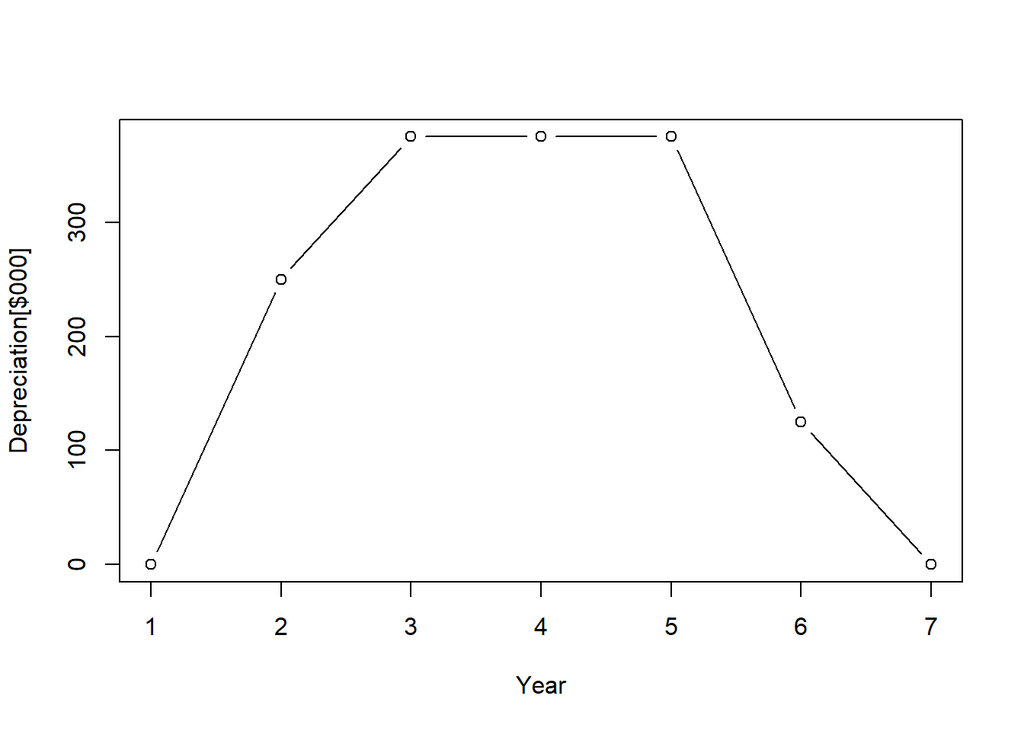

```r
depr<-colSums(depr.matrix)
plot(year,depr/1e3,xlab="Year",ylab="Depreciation[$000]",type ="b" )
```

## Sales and Revenue Block

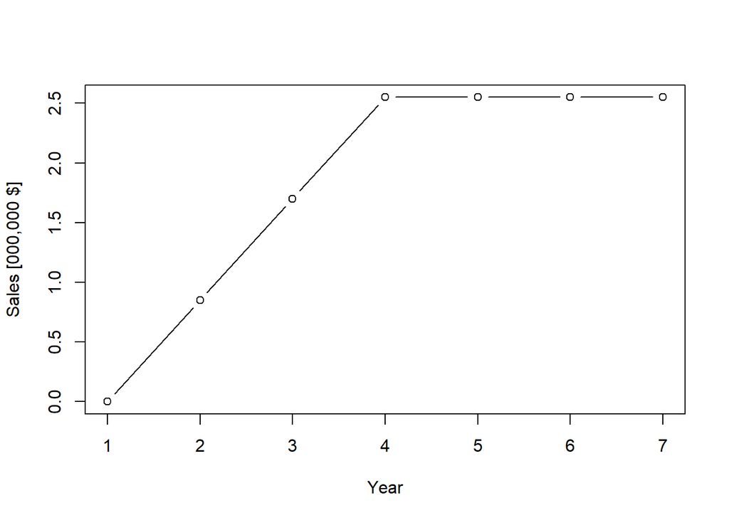

```r
mkt.adoption<-pmin(cumsum(phase>1)/time.to.peak.sales,1)
price.per.software.year<-15000
price.per.user<-300
average.users.per.program<-10
month.per.year<-12
user.arr<-price.per.user*average.users.per.program*month.per.year
price<-price.per.software.year+user.arr
sales<-mkt.adoption*mkt.demand
revenue<-sales*price
plot(year, revenue/1000000,
xlab = "Year",
ylab = "Sales [000,000 $]",
type = "b")
```

## OPEX Block

The OPEX include R&D (research and development) and G&S (general sales and administrative) and is estimated to be 20% of the revenue. The operational cost will start only after phase 1.

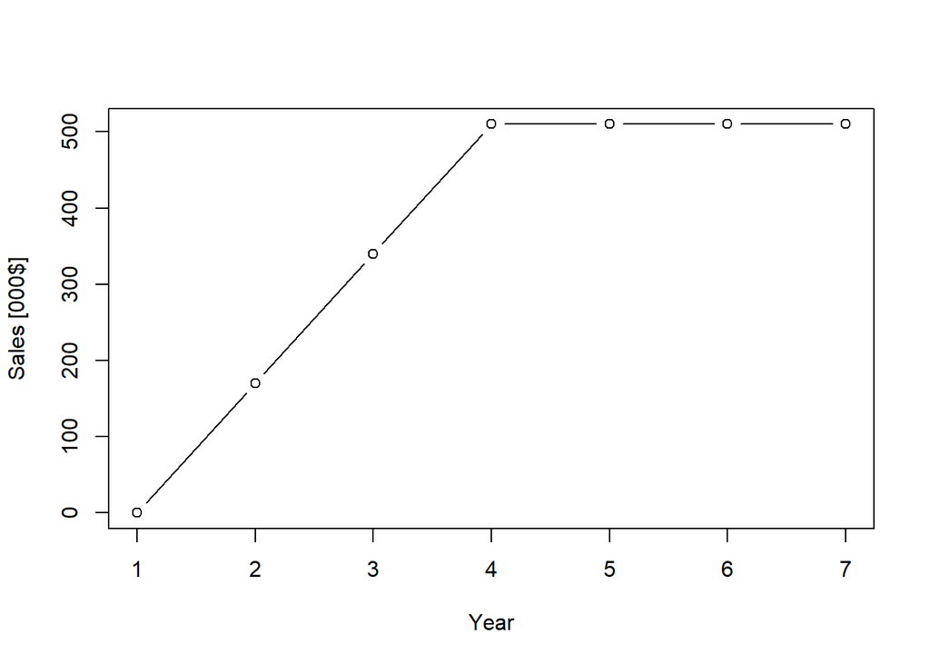

```r
opex<-revenue*0.2
plot(year, opex/1000,
xlab = "Year",
ylab = "Sales [000$]",
type = "b")
```

## Pro Forma Table

- Gross profit = revenue-OPEX
- Operating profit before taxes = Gross profit - OPEX - depreciation
- Operating profit after tax = operating profit before tax-tax
- Cash flow = operating profit after tax + depreciation - CAPEX

```r
gross.profit<-revenue-opex
op.profit.before.tax<-gross.profit-opex-depr
tax<-op.profit.before.tax*kTaxRate/100
op.profit.after.tax<-op.profit.before.tax-tax
cash.flow<-op.profit.after.tax+depr-capex
cum.cah.flow<-cumsum(cash.flow)
```

## Cumulative Cash Flow

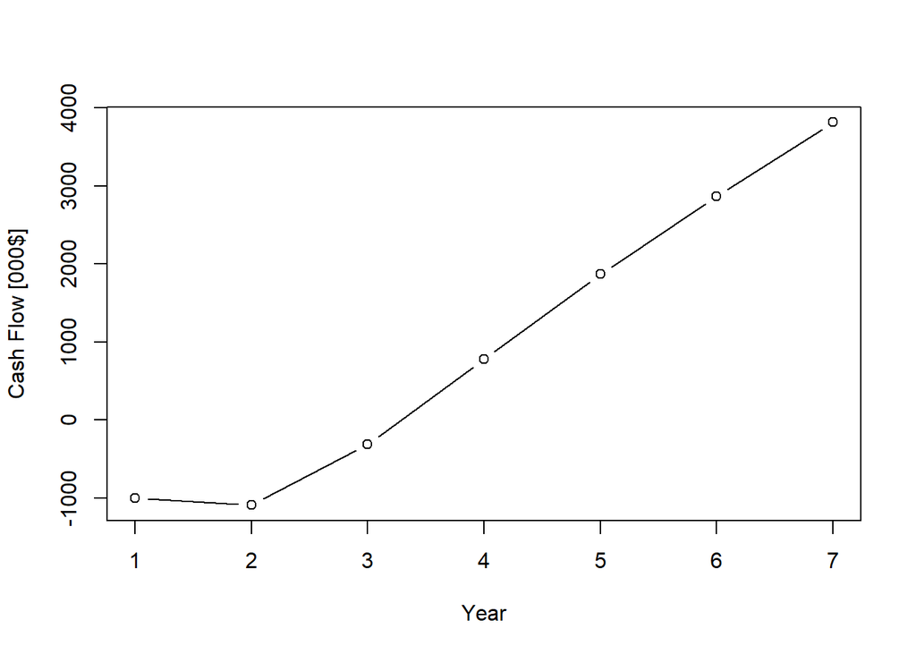

```r
plot(year, cum.cah.flow/1000,xlab = "Year",ylab = "Cash Flow [000$]", type = "b")
```

## Net Present Value

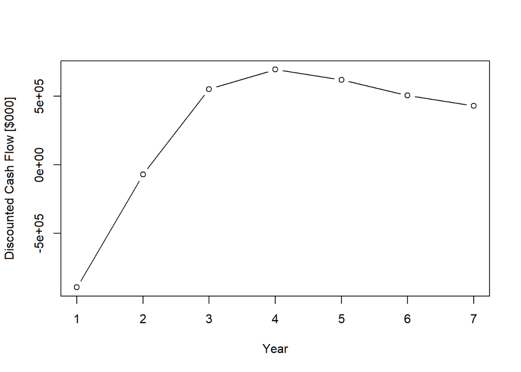

```r
discount.factors <- 1/(1 + kDiscountrate / 100) ^ year
discounted.cash.flow <- cash.flow * discount.factors
plot(year,
discounted.cash.flow,
xlab = "Year",
ylab = "Discounted Cash Flow [$000]",
type = "b")
```

```r
npv <- sum(discounted.cash.flow)
```

**Net Present Value is** 1.834197510^{6}

## Pro Forma Table

```r
pro.forma.vars <- array( c(sales, revenue, gross.profit,
-opex, -depr, op.profit.before.tax, -tax, op.profit.after.tax, depr, -capex, cash.flow ), dim = c(kHorizon, 11))
pro.forma <- data.frame(pro.forma.vars)
pro.forma.headers <- c("Sales [breeding programs]", "Revenue","Gross Profit",
"OPEX", "-Depreciation", "Operating Profit Before Tax", "Tax", "Operating Profit After Tax", "+Depreciation", "CAPEX",
"Cash Flow")
colnames(pro.forma) <- pro.forma.headers
rownames(pro.forma) <- year
pro.forma = t(pro.forma)
pro.forma
```

```
##                                  1             2             3       4       5
## Sales [breeding programs]    0e+00      16.66667      33.33333      50      50
## Revenue                      0e+00  850000.00000 1700000.00000 2550000 2550000
## Gross Profit                 0e+00  680000.00000 1360000.00000 2040000 2040000
## OPEX                         0e+00 -170000.00000 -340000.00000 -510000 -510000
## -Depreciation                0e+00 -250000.00000 -375000.00000 -375000 -375000
## Operating Profit Before Tax  0e+00  260000.00000  645000.00000 1155000 1155000
## Tax                          0e+00  -98800.00000 -245100.00000 -438900 -438900
## Operating Profit After Tax   0e+00  161200.00000  399900.00000  716100  716100
## +Depreciation                0e+00  250000.00000  375000.00000  375000  375000
## CAPEX                       -1e+06 -500000.00000       0.00000       0       0
## Cash Flow                   -1e+06  -88800.00000  774900.00000 1091100 1091100
##                                   6       7
## Sales [breeding programs]        50      50
## Revenue                     2550000 2550000
## Gross Profit                2040000 2040000
## OPEX                        -510000 -510000
## -Depreciation               -125000       0
## Operating Profit Before Tax 1405000 1530000
## Tax                         -533900 -581400
## Operating Profit After Tax   871100  948600
## +Depreciation                125000       0
## CAPEX                             0       0
## Cash Flow                    996100  948600
```

## References

The business model in this post based on a book by Robert D. Brown III *Business Case Analysis with R**